# snATAC-seq demo

Giuditta

2024-02-09

## snATAC-seq demo dataset

The pipeline is fully based, for now, on https://stuartlab.org/signac/articles/pbmc_vignette , SIgnac package, Stuart lab.

In this notebook I will try Signac package guide to analyse a Human PBMC dataset, snATACseq data, 10x Genomics.

```r
setwd("/group/soranzo/giuditta.clerici/snATAC_demo")
```

```r
if (!requireNamespace("EnsDb.Hsapiens.v75", quietly = TRUE))
    BiocManager::install("EnsDb.Hsapiens.v75")
```

```r
if (!require("BiocManager", quietly = TRUE))
    install.packages("BiocManager")
```

```r
BiocManager::install("biovizBase")
library(Signac)
library(Seurat)
library(EnsDb.Hsapiens.v75)
library(ggplot2)
library(patchwork)
```

Signac will use 2 input files:

- Peak/Cell matrix: (like the gene expression count matrix in scRNAseq). Each row is a region of the genome (peak).
- Fragment file: full list of unique fragments across all the cells (not only the ones that maps to peaks)

Create Seurat object:

```r
counts <- Read10X_h5(filename = "./data/atac_v1_pbmc_10k_filtered_peak_bc_matrix.h5")

metadata <- read.csv(
  file = "./data/atac_v1_pbmc_10k_singlecell.csv",
  header = TRUE,
  row.names = 1
)

# with counts matrix create the chromatin assay

chrom_assay <- CreateChromatinAssay(
  counts = counts,
  sep = c(":", "-"),
  fragments = './data/atac_v1_pbmc_10k_fragments.tsv.gz',
  min.cells = 10,
  min.features = 200
)
```

```
## Computing hash
```

```r
# create final Seurat object
pbmc <- CreateSeuratObject(
  counts = chrom_assay,
  assay = "peaks",
  meta.data = metadata
)
```

```r
pbmc
```

```
## An object of class Seurat
## 87561 features across 8728 samples within 1 assay
## Active assay: peaks (87561 features, 0 variable features)
##  2 layers present: counts, data
```

Print some additional information:

```r
pbmc[["peaks"]]
```

```
## ChromatinAssay data with 87561 features for 8728 cells
## Variable features: 0
## Genome:
## Annotation present: FALSE
## Motifs present: FALSE
## Fragment files: 1
```

If the chromatinAssai is the active assay (like in our case) we can call granges to see the genomic ranges associated with each feature.

```r
granges(pbmc)
```

```
## GRanges object with 87561 ranges and 0 metadata columns:
##           seqnames            ranges strand
##              <Rle>         <IRanges>  <Rle>
##       [1]     chr1     565107-565550      *
##       [2]     chr1     569174-569639      *
##       [3]     chr1     713460-714823      *
##       [4]     chr1     752422-753038      *
##       [5]     chr1     762106-763359      *
##       ...      ...               ...    ...
##   [87557]     chrY 58993392-58993760      *
##   [87558]     chrY 58994571-58994823      *
##   [87559]     chrY 58996352-58997331      *
##   [87560]     chrY 59001782-59002175      *
##   [87561]     chrY 59017143-59017246      *
##   -------
##   seqinfo: 24 sequences from an unspecified genome; no seqlengths
```

Add the gene annotations to the pbmc object from human genome:

```r
# extract gene annotations from EnsDb
annotations <- GetGRangesFromEnsDb(ensdb = EnsDb.Hsapiens.v75)
```

[output not shown]

[output cut: 16 more lines]

[output not shown]

```r
# change to UCSC style since the data was mapped to hg19
seqlevels(annotations) <- paste0('chr', seqlevels(annotations))
genome(annotations) <- "hg19"
```

```r
# add the gene information to the object
Annotation(pbmc) <- annotations
```

### QC metrics

Suggested metrics:

The last three metrics can be obtained from CellRanger output (stored in metadata).

```r
# compute nucleosome signal score per cell
pbmc <- NucleosomeSignal(object = pbmc)

# compute TSS enrichment score per cell
pbmc <- TSSEnrichment(object = pbmc, fast = FALSE)
```

```
## Extracting TSS positions
```

```
## Finding + strand cut sites
```

```
## Finding - strand cut sites
```

```
## Computing mean insertion frequency in flanking regions
```

```
## Normalizing TSS score
```

```r
# add blacklist ratio and fraction of reads in peaks
pbmc$pct_reads_in_peaks <- pbmc$peak_region_fragments / pbmc$passed_filters * 100

pbmc$blacklist_ratio <- pbmc$blacklist_region_fragments / pbmc$peak_region_fragments
```

You can visualize these metrics:

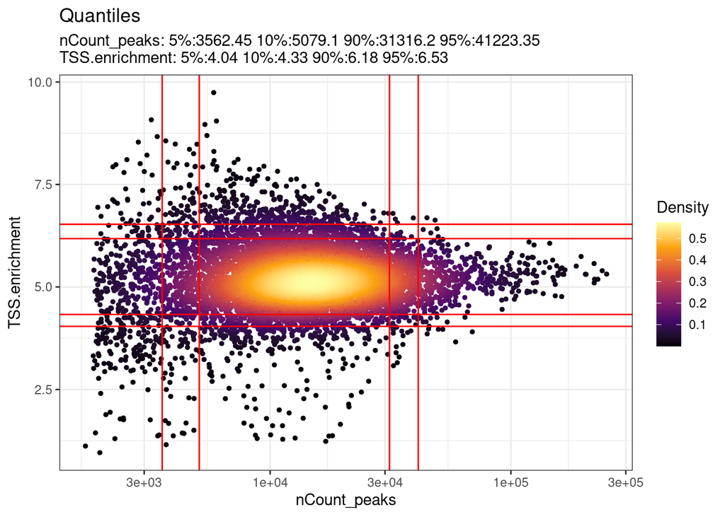

```r
DensityScatter(pbmc,
               x = 'nCount_peaks',
               y = 'TSS.enrichment',
               log_x = TRUE,
               quantiles = TRUE)
```

Plot TSS enrichment signal for different groups of cells using TSSPlot:

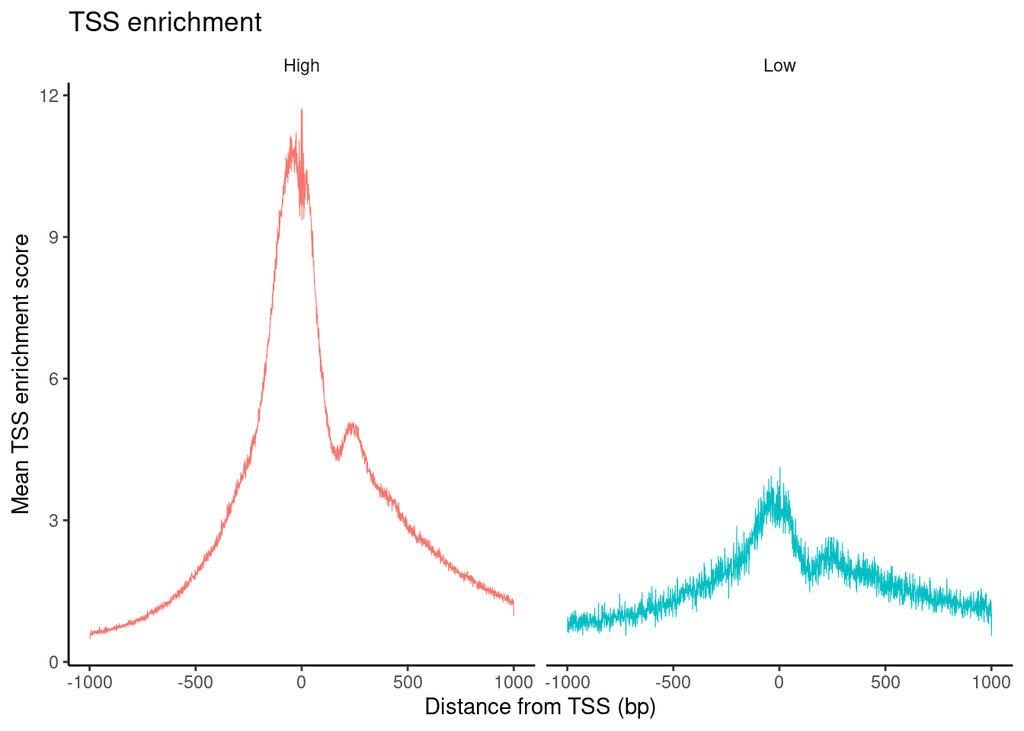

```r
# decide you threshold
threshold <- 3

pbmc$high.tss <- ifelse(pbmc$TSS.enrichment > threshold, 'High', 'Low')

TSSPlot(pbmc, group.by = 'high.tss') + NoLegend()
```

The periodicity of fragment lengths is determined by the spacing between nucleosomes, as well as the positioning of the enzymatic cleavage sites relative to the nucleosome-bound DNA.

In ATAC-seq data, the fragment length periodicity typically manifests as a series of peaks in a histogram of fragment sizes, with peaks occurring at multiples of ~150-200 base pairs. This corresponds to the length of DNA wrapped around a single nucleosome core particle. The periodicity reflects the repeating pattern of nucleosome-bound DNA regions, interspersed with nucleosome-free regions.

It allows researchers to infer the positions and spacing of nucleosomes along the DNA sequence, as well as to identify regions of open chromatin and nucleosome occupancy. Additionally, changes in fragment length periodicity may indicate alterations in chromatin structure or nucleosome positioning under different biological conditions or in response to stimuli.

Grouping Cells by **Nucleosomal Signal Strength**: By examining the fragment length periodicity across all cells, you can identify cells with high or low nucleosomal signal strength. Cells with *high nucleosomal signal strength may exhibit strong periodic patterns* corresponding to well-positioned nucleosomes, while cells with low nucleosomal signal strength may lack clear periodicity, indicating poor nucleosome organization or low-quality data.

Identifying Outliers: Cells that deviate significantly from the expected nucleosomal banding patterns may be considered outliers. For example, cells with an unusual mononucleosomal/nucleosome-free ratio or aberrant fragment length distributions may indicate experimental artifacts or biological differences.

Interpreting Patterns: Cells with typical fragment length periodicity patterns are indicative of successful ATAC-seq experiments, suggesting robust chromatin accessibility profiles and well-defined nucleosome positions. In contrast, cells with atypical patterns may require further investigation to determine the cause of the aberrant signal, such as technical artifacts or biological variability.

To perform this analysis:

Calculate fragment length distributions for each cell’s ATAC-seq data. Assess the periodicity of fragment lengths using methods such as Fourier transform analysis or autocorrelation. Group cells based on nucleosomal signal strength or other relevant metrics, such as the mononucleosomal/nucleosome-free ratio. Visualize the fragment length periodicity patterns for each group of cells to identify outliers and assess overall data quality. Interpret the results in the context of experimental conditions and biological hypotheses. Overall, analyzing fragment length periodicity in ATAC-seq data can provide valuable insights into chromatin structure and function, helping to elucidate regulatory mechanisms and identify aberrant signals that may require further investigation.